# Breast_Cancer_Project_P(V1)

### Importing Packages for building classification models using Machine Learning

```python
#Packages related to general operating system & warnings
import os
import warnings
warnings.filterwarnings('ignore')

#Packages related to data importing, manipulation, exploratory data analysis, data understanding
import numpy as np
import pandas as pd
from pandas import Series, DataFrame
import pandas_profiling
import scipy.stats as stats
import statsmodels.formula.api as smf

#Packages related to data visualizaiton
import seaborn as sns
import matplotlib.pyplot as plt
%matplotlib inline

#Modules related to split the data & gridsearch
from sklearn.model_selection import train_test_split, GridSearchCV

#Module related to calculation of metrics
from sklearn import metrics

#Module related to VIF
from statsmodels.stats.outliers_influence import variance_inflation_factor

#Moudles related to feature selection
from sklearn.feature_selection import RFE, SelectKBest, chi2,f_classif, f_regression

#Modules related to saving python objects permanantly
from sklearn.externals import joblib

#Dumping model into current directory: joblib.dump(model_xg,"my_model.pkl")
#Loading model: my_model_loaded=joblib.load("my_model.pkl")

from sklearn.linear_model import LogisticRegression
from sklearn.neighbors import KNeighborsClassifier
from sklearn.tree import DecisionTreeClassifier
from sklearn.ensemble import BaggingClassifier,RandomForestClassifier
from sklearn.ensemble import GradientBoostingClassifier, AdaBoostClassifier
from xgboost import XGBClassifier
from sklearn.naive_bayes import BernoulliNB, MultinomialNB, GaussianNB
from sklearn.svm import SVC
from sklearn.neural_network import MLPClassifier, MLPRegressor
```

#### Load the data

```python
df = pd.read_csv("BreastCancerData.csv")
```

```python
df.head()
```

|  | id | diagnosis | radius_mean | texture_mean | perimeter_mean | area_mean | smoothness_mean | compactness_mean | concavity_mean | concave points_mean | ... | texture_worst | perimeter_worst | area_worst | smoothness_worst | compactness_worst | concavity_worst | concave points_worst | symmetry_worst | fractal_dimension_worst | Unnamed: 32 |
| --- | --- | --- | --- | --- | --- | --- | --- | --- | --- | --- | --- | --- | --- | --- | --- | --- | --- | --- | --- | --- | --- |
| 0 | 842302 | M | 17.99 | 10.38 | 122.80 | 1001.0 | 0.11840 | 0.27760 | 0.3001 | 0.14710 | ... | 17.33 | 184.60 | 2019.0 | 0.1622 | 0.6656 | 0.7119 | 0.2654 | 0.4601 | 0.11890 | NaN |
| 1 | 842517 | M | 20.57 | 17.77 | 132.90 | 1326.0 | 0.08474 | 0.07864 | 0.0869 | 0.07017 | ... | 23.41 | 158.80 | 1956.0 | 0.1238 | 0.1866 | 0.2416 | 0.1860 | 0.2750 | 0.08902 | NaN |
| 2 | 84300903 | M | 19.69 | 21.25 | 130.00 | 1203.0 | 0.10960 | 0.15990 | 0.1974 | 0.12790 | ... | 25.53 | 152.50 | 1709.0 | 0.1444 | 0.4245 | 0.4504 | 0.2430 | 0.3613 | 0.08758 | NaN |
| 3 | 84348301 | M | 11.42 | 20.38 | 77.58 | 386.1 | 0.14250 | 0.28390 | 0.2414 | 0.10520 | ... | 26.50 | 98.87 | 567.7 | 0.2098 | 0.8663 | 0.6869 | 0.2575 | 0.6638 | 0.17300 | NaN |
| 4 | 84358402 | M | 20.29 | 14.34 | 135.10 | 1297.0 | 0.10030 | 0.13280 | 0.1980 | 0.10430 | ... | 16.67 | 152.20 | 1575.0 | 0.1374 | 0.2050 | 0.4000 | 0.1625 | 0.2364 | 0.07678 | NaN |

5 rows × 33 columns

**Removing The unnecessary Columns**

```python
df.drop('id',axis=1,inplace=True)
df.drop('Unnamed: 32',axis=1,inplace=True)
```

**Dimension of DataFrame**

```python
df.shape
```

```
(569, 31)
```

**Checking Target Variable**

```python
df.diagnosis.unique()
```

```
array(['M', 'B'], dtype=object)
```

**Converting Target Variable in form of 1 and 0 by mapping**

```python
df['diagnosis'] = df['diagnosis'].map({'M':1,'B':0})
```

```python
df.head(2)
```

|  | diagnosis | radius_mean | texture_mean | perimeter_mean | area_mean | smoothness_mean | compactness_mean | concavity_mean | concave points_mean | symmetry_mean | ... | radius_worst | texture_worst | perimeter_worst | area_worst | smoothness_worst | compactness_worst | concavity_worst | concave points_worst | symmetry_worst | fractal_dimension_worst |
| --- | --- | --- | --- | --- | --- | --- | --- | --- | --- | --- | --- | --- | --- | --- | --- | --- | --- | --- | --- | --- | --- |
| 0 | 1 | 17.99 | 10.38 | 122.8 | 1001.0 | 0.11840 | 0.27760 | 0.3001 | 0.14710 | 0.2419 | ... | 25.38 | 17.33 | 184.6 | 2019.0 | 0.1622 | 0.6656 | 0.7119 | 0.2654 | 0.4601 | 0.11890 |
| 1 | 1 | 20.57 | 17.77 | 132.9 | 1326.0 | 0.08474 | 0.07864 | 0.0869 | 0.07017 | 0.1812 | ... | 24.99 | 23.41 | 158.8 | 1956.0 | 0.1238 | 0.1866 | 0.2416 | 0.1860 | 0.2750 | 0.08902 |

2 rows × 31 columns

## Exploratory Data Analysis

```python
df.describe()
```

|  | diagnosis | radius_mean | texture_mean | perimeter_mean | area_mean | smoothness_mean | compactness_mean | concavity_mean | concave points_mean | symmetry_mean | ... | radius_worst | texture_worst | perimeter_worst | area_worst | smoothness_worst | compactness_worst | concavity_worst | concave points_worst | symmetry_worst | fractal_dimension_worst |
| --- | --- | --- | --- | --- | --- | --- | --- | --- | --- | --- | --- | --- | --- | --- | --- | --- | --- | --- | --- | --- | --- |
| count | 569.000000 | 569.000000 | 569.000000 | 569.000000 | 569.000000 | 569.000000 | 569.000000 | 569.000000 | 569.000000 | 569.000000 | ... | 569.000000 | 569.000000 | 569.000000 | 569.000000 | 569.000000 | 569.000000 | 569.000000 | 569.000000 | 569.000000 | 569.000000 |
| mean | 0.372583 | 14.127292 | 19.289649 | 91.969033 | 654.889104 | 0.096360 | 0.104341 | 0.088799 | 0.048919 | 0.181162 | ... | 16.269190 | 25.677223 | 107.261213 | 880.583128 | 0.132369 | 0.254265 | 0.272188 | 0.114606 | 0.290076 | 0.083946 |
| std | 0.483918 | 3.524049 | 4.301036 | 24.298981 | 351.914129 | 0.014064 | 0.052813 | 0.079720 | 0.038803 | 0.027414 | ... | 4.833242 | 6.146258 | 33.602542 | 569.356993 | 0.022832 | 0.157336 | 0.208624 | 0.065732 | 0.061867 | 0.018061 |
| min | 0.000000 | 6.981000 | 9.710000 | 43.790000 | 143.500000 | 0.052630 | 0.019380 | 0.000000 | 0.000000 | 0.106000 | ... | 7.930000 | 12.020000 | 50.410000 | 185.200000 | 0.071170 | 0.027290 | 0.000000 | 0.000000 | 0.156500 | 0.055040 |
| 25% | 0.000000 | 11.700000 | 16.170000 | 75.170000 | 420.300000 | 0.086370 | 0.064920 | 0.029560 | 0.020310 | 0.161900 | ... | 13.010000 | 21.080000 | 84.110000 | 515.300000 | 0.116600 | 0.147200 | 0.114500 | 0.064930 | 0.250400 | 0.071460 |
| 50% | 0.000000 | 13.370000 | 18.840000 | 86.240000 | 551.100000 | 0.095870 | 0.092630 | 0.061540 | 0.033500 | 0.179200 | ... | 14.970000 | 25.410000 | 97.660000 | 686.500000 | 0.131300 | 0.211900 | 0.226700 | 0.099930 | 0.282200 | 0.080040 |
| 75% | 1.000000 | 15.780000 | 21.800000 | 104.100000 | 782.700000 | 0.105300 | 0.130400 | 0.130700 | 0.074000 | 0.195700 | ... | 18.790000 | 29.720000 | 125.400000 | 1084.000000 | 0.146000 | 0.339100 | 0.382900 | 0.161400 | 0.317900 | 0.092080 |
| max | 1.000000 | 28.110000 | 39.280000 | 188.500000 | 2501.000000 | 0.163400 | 0.345400 | 0.426800 | 0.201200 | 0.304000 | ... | 36.040000 | 49.540000 | 251.200000 | 4254.000000 | 0.222600 | 1.058000 | 1.252000 | 0.291000 | 0.663800 | 0.207500 |

8 rows × 31 columns

**Visualizing Heat Map For correlation**

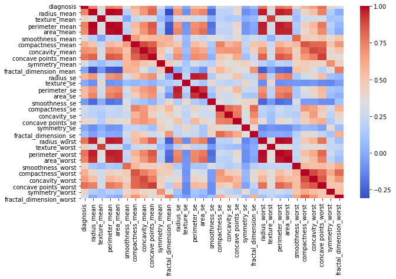

```python
# visualize correlation matrix in Seaborn using a heatmap
figure = plt.figure(figsize=(10,6))
sns.heatmap(df.corr(),cmap= 'coolwarm')
```

```python
profile_report = pandas_profiling.ProfileReport(df)
```

```python
profile_report.to_file('profile_report.html')
```

#### As we can see from the profiling report that:-

- area_worst is highly correlated with area_mean (ρ = 0.9592133256)
- concave_points_worst is highly correlated with concave_points_mean (ρ = 0.9101553143)
- concavity_mean is highly correlated with concave_points_mean (ρ = 0.9213910264)
- perimeter_mean is highly correlated with area_worst (ρ = 0.941549808)
- perimeter_se is highly correlated with area_se (ρ = 0.937655407)
- perimeter_worst is highly correlated with perimeter_mean (ρ = 0.970386887)
- radius_mean is highly correlated with perimeter_worst (ρ = 0.965136514)
- radius_se is highly correlated with perimeter_se (ρ = 0.972793677)
- radius_worst is highly correlated with radius_mean (ρ = 0.9695389726)
- texture_worst is highly correlated with texture_mean (ρ = 0.9120445888)

**So we can reject the highly correlated variables in the later stage**

#### Distribution of Target Variable

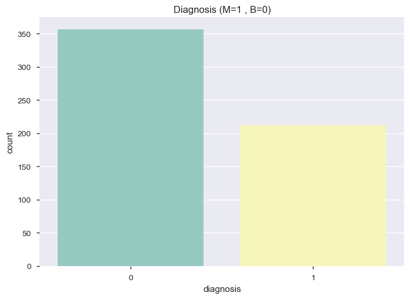

```python
plt.title('Diagnosis (M=1 , B=0)')
sns.countplot(df["diagnosis"],palette="Set3")
plt.show()
```

```python
features_mean=list(df.columns[1:11])
# split dataframe into two based on diagnosis
dfM=df[df['diagnosis'] ==1]
dfB=df[df['diagnosis'] ==0]
```

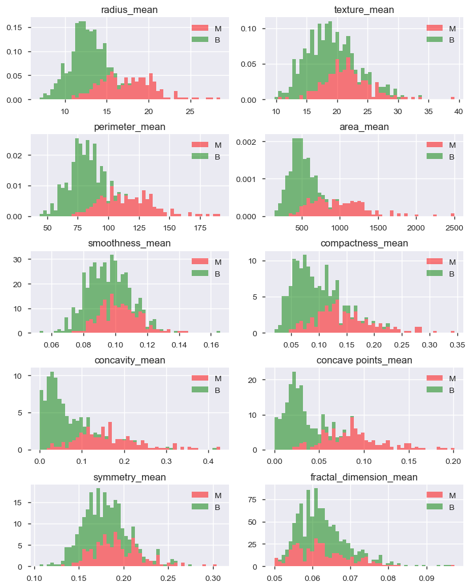

```python
#Stack the data
plt.rcParams.update({'font.size': 8})
fig, axes = plt.subplots(nrows=5, ncols=2, figsize=(8,10))
axes = axes.ravel()
for idx,ax in enumerate(axes):
    ax.figure
    binwidth= (max(df[features_mean[idx]]) - min(df[features_mean[idx]]))/50
    ax.hist([dfM[features_mean[idx]],dfB[features_mean[idx]]], bins=np.arange(min(df[features_mean[idx]]), max(df[features_mean[idx]]) + binwidth, binwidth) , alpha=0.5,stacked=True, normed = True, label=['M','B'],color=['r','g'])
    ax.legend(loc='upper right')
    ax.set_title(features_mean[idx])
plt.tight_layout()
plt.show()
```

```python
#Renaming the columsns by replacing special characters with underscore
df.columns = [ i.replace(' ', '_') for i in df.columns]
```

## Feature Reduction

**Dropping the highly correated variables**

```python
df.drop(['area_worst','concavity_mean','perimeter_se','perimeter_worst',
        'radius_worst','texture_worst','concave_points_worst','radius_se','perimeter_mean','radius_mean'],axis=1,inplace=True)
```

[output not shown]

```python
df.shape
```

```
(569, 21)
```

### 1) Univariate Regression

```python
somersd_df = pd.DataFrame()
for var in df.columns.difference(['diagnosis']):
    result = smf.logit(formula = str('diagnosis ~ ')+str(var), data=df).fit()
    somers_d = 2*metrics.roc_auc_score(df.diagnosis, result.predict()) - 1
    temp = pd.DataFrame([var,somers_d]).T
    temp.columns = ['VariableName', 'SomersD']
    somersd_df = pd.concat([somersd_df, temp], axis=0)
```

[output not shown]

```python
imp_vars_SD = somersd_df.sort_values('SomersD', ascending=False).head(10)
```

**Important variables through SomersD method**

```python
imp_vars_SD
```

|  | VariableName | SomersD |
| --- | --- | --- |
| 0 | concave_points_mean | 0.928875 |
| 0 | area_mean | 0.876632 |
| 0 | area_se | 0.852822 |
| 0 | concavity_worst | 0.842728 |
| 0 | compactness_mean | 0.727565 |
| 0 | compactness_worst | 0.724605 |
| 0 | concave_points_se | 0.583584 |
| 0 | concavity_se | 0.561638 |
| 0 | texture_mean | 0.551649 |
| 0 | smoothness_worst | 0.508113 |

```python
imp_vars_somersD = list(imp_vars_SD.VariableName.values)
```

### 2) RFE(Recursive Feature Elimination)

```python
X = df[df.columns.difference(['diagnosis'])]
classifier = RandomForestClassifier()
rfe = RFE(classifier, 10)
rfe = rfe.fit(X, df[['diagnosis']] )
```

```python
imp_vars_RFE = list(X.columns[rfe.support_])
```

**Important Variables by RFE method**

```python
imp_vars_RFE
```

```
['area_mean',
 'area_se',
 'compactness_mean',
 'compactness_worst',
 'concave_points_mean',
 'concavity_worst',
 'fractal_dimension_mean',
 'smoothness_mean',
 'smoothness_worst',
 'texture_mean']
```

### 3) Select K Best

```python
X = df[df.columns.difference(['diagnosis'])]
SKB = SelectKBest(f_classif, k=10).fit(X, df[['diagnosis']] )
```

```python
SKB.get_support()
imp_vars_SKB = list(X.columns[SKB.get_support()])
```

**Important Variables by Select K best**

```python
imp_vars_SKB
```

```
['area_mean',
 'area_se',
 'compactness_mean',
 'compactness_worst',
 'concave_points_mean',
 'concave_points_se',
 'concavity_worst',
 'smoothness_worst',
 'symmetry_worst',
 'texture_mean']
```

```python
Final_list = list(set(imp_vars_SKB +imp_vars_somersD + imp_vars_RFE))
```

### Making Final List Of Important Variables

```python
Final_list
```

```
['area_mean',
 'compactness_mean',
 'fractal_dimension_mean',
 'smoothness_worst',
 'symmetry_worst',
 'texture_mean',
 'area_se',
 'concavity_se',
 'smoothness_mean',
 'concavity_worst',
 'compactness_worst',
 'concave_points_se',
 'concave_points_mean']
```

# 1:- Logistic regression using statsmodels(Traditional Approach)

**Splitting the data into train and test**

```python
train, test = train_test_split(df, test_size=0.3, random_state=0)
```

**Initialising and fitting the model**

```python
logreg = smf.logit(formula='diagnosis~area_se+concavity_worst +concave_points_mean+compactness_worst+concave_points_se+texture_mean+smoothness_worst+compactness_mean+area_mean+symmetry_worst+concavity_se', data=train)
```

```python
result = logreg.fit()
```

```
Optimization terminated successfully.
         Current function value: 0.058178
         Iterations 13
```

```python
print(result.summary2())
```

```
                             Results: Logit
========================================================================
Model:                 Logit              Pseudo R-squared:   0.912
Dependent Variable:    diagnosis          AIC:                70.3095
Date:                  2020-04-21 15:20   BIC:                118.1469
No. Observations:      398                Log-Likelihood:     -23.155
Df Model:              11                 LL-Null:            -263.17
Df Residuals:          386                LLR p-value:        5.7722e-96
Converged:             1.0000             Scale:              1.0000
No. Iterations:        13.0000
------------------------------------------------------------------------
                      Coef.   Std.Err.    z    P>|z|    [0.025   0.975]
------------------------------------------------------------------------
Intercept            -31.9109   8.0240 -3.9770 0.0001  -47.6376 -16.1843
area_se                0.2044   0.0646  3.1641 0.0016    0.0778   0.3310
concavity_worst       37.6353  14.5068  2.5943 0.0095    9.2025  66.0681
concave_points_mean   48.6577  57.2578  0.8498 0.3954  -63.5656 160.8810
compactness_worst    -14.4421  14.8469 -0.9727 0.3307  -43.5416  14.6573
concave_points_se    178.7022 240.4024  0.7433 0.4573 -292.4778 649.8821
texture_mean           0.3948   0.1219  3.2396 0.0012    0.1559   0.6336
smoothness_worst      29.8534  35.4248  0.8427 0.3994  -39.5778  99.2847
compactness_mean     -24.2611  39.7309 -0.6106 0.5414 -102.1323  53.6101
area_mean              0.0061   0.0042  1.4597 0.1444   -0.0021   0.0143
symmetry_worst        22.5894  12.6076  1.7917 0.0732   -2.1210  47.2999
concavity_se        -182.1319  91.5726 -1.9889 0.0467 -361.6110  -2.6528
========================================================================
```

```python
logreg = smf.logit(formula='diagnosis~area_se+concavity_worst +concave_points_mean+texture_mean+compactness_mean+area_mean+symmetry_worst+concavity_se', data=train)
```

```python
result = logreg.fit()

print(result.summary2())
```

```
Optimization terminated successfully.
         Current function value: 0.061273
         Iterations 12
                             Results: Logit
========================================================================
Model:                 Logit              Pseudo R-squared:   0.907
Dependent Variable:    diagnosis          AIC:                66.7736
Date:                  2020-04-21 15:20   BIC:                102.6517
No. Observations:      398                Log-Likelihood:     -24.387
Df Model:              8                  LL-Null:            -263.17
Df Residuals:          389                LLR p-value:        4.5429e-98
Converged:             1.0000             Scale:              1.0000
No. Iterations:        12.0000
------------------------------------------------------------------------
                      Coef.   Std.Err.    z    P>|z|    [0.025   0.975]
------------------------------------------------------------------------
Intercept            -26.4028   6.2606 -4.2173 0.0000  -38.6734 -14.1322
area_se                0.2118   0.0632  3.3482 0.0008    0.0878   0.3357
concavity_worst       27.8403   7.1096  3.9159 0.0001   13.9057  41.7748
concave_points_mean  106.3965  40.4601  2.6297 0.0085   27.0961 185.6969
texture_mean           0.3721   0.1137  3.2728 0.0011    0.1492   0.5949
compactness_mean     -54.3968  29.2061 -1.8625 0.0625 -111.6397   2.8461
area_mean              0.0030   0.0032  0.9409 0.3468   -0.0033   0.0094
symmetry_worst        24.9781  12.0378  2.0750 0.0380    1.3845  48.5718
concavity_se        -130.1862  48.1648 -2.7029 0.0069 -224.5876 -35.7849
========================================================================
```

#### Accuracy Metrics

```python
train_gini = 2*metrics.roc_auc_score(train['diagnosis'], result.predict(train)) - 1
print("The Gini Index for the model built on the Train Data is : ", train_gini)

test_gini = 2*metrics.roc_auc_score(test['diagnosis'], result.predict(test)) - 1
print("The Gini Index for the model built on the Test Data is : ", test_gini)

train_auc = metrics.roc_auc_score(train['diagnosis'], result.predict(train))
test_auc = metrics.roc_auc_score(test['diagnosis'], result.predict(test))

print("The AUC for the model built on the Train Data is : ", train_auc)
print("The AUC for the model built on the Test Data is : ", test_auc)
```

```
The Gini Index for the model built on the Train Data is :  0.9941780544998786
The Gini Index for the model built on the Test Data is :  0.980893592004703
The AUC for the model built on the Train Data is :  0.9970890272499393
The AUC for the model built on the Test Data is :  0.9904467960023515
```

```python
## Intuition behind ROC curve - predicted probability as a tool for separating the '1's and '0's
train_predicted_prob = pd.DataFrame(result.predict(train))
train_predicted_prob.columns = ['prob']
train_actual = train['diagnosis']
# making a DataFrame with actual and prob columns
train_predict = pd.concat([train_actual, train_predicted_prob], axis=1)
train_predict.columns = ['actual','prob']
train_predict.head()
```

|  | actual | prob |
| --- | --- | --- |
| 478 | 0 | 4.908916e-05 |
| 303 | 0 | 3.561322e-06 |
| 155 | 0 | 4.527577e-03 |
| 186 | 1 | 9.993928e-01 |
| 101 | 0 | 1.550201e-07 |

```python
## Intuition behind ROC curve - predicted probability as a tool for separating the '1's and '0's
test_predicted_prob = pd.DataFrame(result.predict(test))
test_predicted_prob.columns = ['prob']
test_actual = test['diagnosis']
# making a DataFrame with actual and prob columns
test_predict = pd.concat([test_actual, test_predicted_prob], axis=1)
test_predict.columns = ['actual','prob']
test_predict.head()
```

|  | actual | prob |
| --- | --- | --- |
| 512 | 1 | 0.999920 |
| 457 | 0 | 0.013806 |
| 439 | 0 | 0.000125 |
| 298 | 0 | 0.005484 |
| 37 | 0 | 0.000088 |

```python
train## Intuition behind ROC curve - confusion matrix for each different cut-off shows trade off in sensitivity and specificity
roc_like_df = pd.DataFrame()
train_temp = train_predict.copy()

for cut_off in np.linspace(0,1,50):
    train_temp['cut_off'] = cut_off
    train_temp['predicted'] = train_temp['prob'].apply(lambda x: 0.0 if x < cut_off else 1.0)
    train_temp['tp'] = train_temp.apply(lambda x: 1.0 if x['actual']==1.0 and x['predicted']==1 else 0.0, axis=1)
    train_temp['fp'] = train_temp.apply(lambda x: 1.0 if x['actual']==0.0 and x['predicted']==1 else 0.0, axis=1)
    train_temp['tn'] = train_temp.apply(lambda x: 1.0 if x['actual']==0.0 and x['predicted']==0 else 0.0, axis=1)
    train_temp['fn'] = train_temp.apply(lambda x: 1.0 if x['actual']==1.0 and x['predicted']==0 else 0.0, axis=1)
    sensitivity = train_temp['tp'].sum() / (train_temp['tp'].sum() + train_temp['fn'].sum())
    specificity = train_temp['tn'].sum() / (train_temp['tn'].sum() + train_temp['fp'].sum())
    accuracy = (train_temp['tp'].sum()  + train_temp['tn'].sum() ) / (train_temp['tp'].sum() + train_temp['fn'].sum() + train_temp['tn'].sum() + train_temp['fp'].sum())
    roc_like_table = pd.DataFrame([cut_off, sensitivity, specificity, accuracy]).T
    roc_like_table.columns = ['cutoff', 'sensitivity', 'specificity', 'accuracy']
    roc_like_df = pd.concat([roc_like_df, roc_like_table], axis=0)
```

```python
roc_like_df.head()
```

|  | cutoff | sensitivity | specificity | accuracy |
| --- | --- | --- | --- | --- |
| 0 | 0.000000 | 1.000000 | 0.000000 | 0.374372 |
| 0 | 0.020408 | 1.000000 | 0.819277 | 0.886935 |
| 0 | 0.040816 | 0.993289 | 0.883534 | 0.924623 |
| 0 | 0.061224 | 0.993289 | 0.899598 | 0.934673 |
| 0 | 0.081633 | 0.979866 | 0.919679 | 0.942211 |

```python
## Finding ideal cut-off for checking if this remains same in OOS validation
roc_like_df['total'] = roc_like_df['sensitivity'] + roc_like_df['specificity']
```

```python
roc_like_df.head()
```

|  | cutoff | sensitivity | specificity | accuracy | total |
| --- | --- | --- | --- | --- | --- |
| 0 | 0.000000 | 1.000000 | 0.000000 | 0.374372 | 1.000000 |
| 0 | 0.020408 | 1.000000 | 0.819277 | 0.886935 | 1.819277 |
| 0 | 0.040816 | 0.993289 | 0.883534 | 0.924623 | 1.876823 |
| 0 | 0.061224 | 0.993289 | 0.899598 | 0.934673 | 1.892887 |
| 0 | 0.081633 | 0.979866 | 0.919679 | 0.942211 | 1.899544 |

```python
#Cut-off based on highest sum(sensitivity+specicity)   - common way of identifying cut-off
roc_like_df[roc_like_df['total']==roc_like_df['total'].max()]
```

|  | cutoff | sensitivity | specificity | accuracy | total |
| --- | --- | --- | --- | --- | --- |
| 0 | 0.387755 | 0.973154 | 0.983936 | 0.979899 | 1.95709 |
| 0 | 0.408163 | 0.973154 | 0.983936 | 0.979899 | 1.95709 |
| 0 | 0.428571 | 0.973154 | 0.983936 | 0.979899 | 1.95709 |
| 0 | 0.448980 | 0.973154 | 0.983936 | 0.979899 | 1.95709 |

```python
#Choosen Best Cut-off is 0.44 based on highest (sensitivity+specicity)

test_predict['predicted'] = test_predict['prob'].apply(lambda x: 1 if x > 0.44 else 0)
train_predict['predicted'] = train_predict['prob'].apply(lambda x: 1 if x > 0.44 else 0)
```

```python
train_predict.head()
```

|  | actual | prob | predicted |
| --- | --- | --- | --- |
| 478 | 0 | 4.908916e-05 | 0 |
| 303 | 0 | 3.561322e-06 | 0 |
| 155 | 0 | 4.527577e-03 | 0 |
| 186 | 1 | 9.993928e-01 | 1 |
| 101 | 0 | 1.550201e-07 | 0 |

```python
print("The overall accuracy score for the Train Data is : ", metrics.accuracy_score(train_predict.actual, train_predict.predicted))
print("The overall accuracy score for the Test Data  is : ", metrics.accuracy_score(test_predict.actual, test_predict.predicted))
```

```
The overall accuracy score for the Train Data is :  0.9798994974874372
The overall accuracy score for the Test Data  is :  0.9473684210526315
```

```python
print(metrics.classification_report(train_predict.actual, train_predict.predicted))
```

```
              precision    recall  f1-score   support

           0       0.98      0.98      0.98       249
           1       0.97      0.97      0.97       149

    accuracy                           0.98       398
   macro avg       0.98      0.98      0.98       398
weighted avg       0.98      0.98      0.98       398
```

### Performing logistic Regression using K-Fold validation manually

```python
from sklearn.model_selection import cross_val_score, KFold
kfold = KFold(n_splits=10, random_state=7)
modelCV = LogisticRegression()
scoring = 'accuracy'
results = cross_val_score(modelCV, train_x, train_y, cv=kfold, scoring=scoring)
print("10-fold cross validation average accuracy: %.3f" % (results.mean()))
```

```
10-fold cross validation average accuracy: 0.942
```

```python
results
```

```
array([0.95      , 0.95      , 0.95      , 0.925     , 0.925     ,
       0.925     , 0.975     , 0.975     , 0.87179487, 0.97435897])
```

# Machine learning

### Splitting the data in train and test for ML algorithms

```python
df.shape
```

```
(569, 21)
```

```python
df.head(2)
```

|  | diagnosis | texture_mean | area_mean | smoothness_mean | compactness_mean | concave_points_mean | symmetry_mean | fractal_dimension_mean | texture_se | area_se | ... | compactness_se | concavity_se | concave_points_se | symmetry_se | fractal_dimension_se | smoothness_worst | compactness_worst | concavity_worst | symmetry_worst | fractal_dimension_worst |
| --- | --- | --- | --- | --- | --- | --- | --- | --- | --- | --- | --- | --- | --- | --- | --- | --- | --- | --- | --- | --- | --- |
| 0 | 1 | 10.38 | 1001.0 | 0.11840 | 0.27760 | 0.14710 | 0.2419 | 0.07871 | 0.9053 | 153.40 | ... | 0.04904 | 0.05373 | 0.01587 | 0.03003 | 0.006193 | 0.1622 | 0.6656 | 0.7119 | 0.4601 | 0.11890 |
| 1 | 1 | 17.77 | 1326.0 | 0.08474 | 0.07864 | 0.07017 | 0.1812 | 0.05667 | 0.7339 | 74.08 | ... | 0.01308 | 0.01860 | 0.01340 | 0.01389 | 0.003532 | 0.1238 | 0.1866 | 0.2416 | 0.2750 | 0.08902 |

2 rows × 21 columns

```python
#Independent columns
Ind_cols = df.columns.difference(['diagnosis'])
```

```python
#Considering Significant Variables for Machine Learning algorithms
train_x, test_x, train_y, test_y = train_test_split(df[Ind_cols],df.diagnosis, test_size=0.3, random_state=1234)
```

[output not shown]

# 2:- K-Nearest Neighbors

##### Important Tuning Parameters for KNN:

- n_neighbors - The number of nearest neighbors K in the K-NN algorithm
- weights - weight function used in predictions.

```python
from sklearn.preprocessing import StandardScaler
```

```python
#Standardization of data
sc = StandardScaler()
std_data = sc.fit_transform(train_x)
```

```python
std_data_train = pd.DataFrame(std_data, columns=train_x.columns, index = train_x.index )
```

```python
std_data_test = pd.DataFrame(sc.transform(test_x), columns=test_x.columns, index = test_x.index )
```

```python
#Using GridsearchCV with standrardized data
param_grid = {'n_neighbors':[3,4,5,6,7,8,9,10,11,12],
              'weights': ['uniform', 'distance']}
knn = GridSearchCV(KNeighborsClassifier(), param_grid = param_grid, cv=5, scoring = 'f1_weighted')
knn.fit(std_data_train, train_y)
```

```python
knn.best_score_
```

[output not shown]

```python
train_pred = knn.predict(std_data_train)
test_pred = knn.predict(std_data_test)
```

```python
print(metrics.classification_report(train_y, train_pred))
```

[output not shown]

```python
print(metrics.classification_report(test_y, test_pred))
```

[output not shown]

```python
print("The overall accuracy score for the Train Data is : ", metrics.accuracy_score(train_y, train_pred))
print("The overall accuracy score for the Test Data  is : ", metrics.accuracy_score(test_y, test_pred))
```

[output not shown]

# 3:- Decision Trees

##### Important Tuning Parameters for DT:

- criterion - measure for quality of a split
- max_depth - The maximum depth of the tree.
- max_leaf_nodes - Number of features to consider when looking for the best split
- min_samples_leaf - The minimum number of samples required to be a leaf node. This may have effect of smoothing the model.
- min_sample_split - The minimum number of samples required to split an internal node.

#### Fine Tuning the parameters

```python
param_grid = {'max_depth': np.arange(3, 5),
             'max_features': np.arange(3,5)}
```

```python
tree = GridSearchCV(DecisionTreeClassifier(), param_grid, cv = 5)
tree.fit( train_x, train_y )
```

```python
tree.best_score_
```

[output not shown]

```python
tree.best_params_
```

[output not shown]

```python
train_pred = tree.predict(train_x)
test_pred = tree.predict(test_x)
```

```python
print("The overall accuracy score for the Train Data is : ", metrics.accuracy_score(train_y, train_pred))
print("The overall accuracy score for the Test Data  is : ", metrics.accuracy_score(test_y, test_pred))
```

[output not shown]

```python
print(metrics.classification_report(train_y, train_pred))
```

[output not shown]

```python
print(metrics.classification_report(test_y, test_pred))
```

[output not shown]

# 4:- Bagging

```python
from sklearn.ensemble import BaggingClassifier
```

**Tuning parameters**

```python
pargrid_ada = {'n_estimators': [50, 60, 70, 80, 90, 100]}

gscv_bagging = GridSearchCV(estimator=BaggingClassifier(),
                        param_grid=pargrid_ada,
                        cv=5,
                        verbose=True, n_jobs=-1)
```

```python
gscv_results = gscv_bagging.fit(train_x, train_y)
```

```python
gscv_results.best_score_
```

[output not shown]

```python
train_pred = gscv_results.predict(train_x)
test_pred = gscv_results.predict(test_x)
```

```python
print(metrics.classification_report(train_y, train_pred))
```

[output not shown]

```python
print(metrics.classification_report(test_y, test_pred))
```

[output not shown]

# 5:- Random Forest

##### Important Tuning Parameters for Random Forest:

- criterion - measure for quality of a split
- max_depth - The maximum depth of the tree.
- max_leaf_nodes - Number of features to consider when looking for the best split
- min_samples_leaf - The minimum number of samples required to be a leaf node. This may have effect of smoothing the model.
- min_sample_split - The minimum number of samples required to split an internal node.
- n_estimators - The number of trees in the forest
- max_features - Number of features to consider when looking for the best split

```python
from sklearn.ensemble import RandomForestClassifier
```

```python
pargrid_ada = {'n_estimators': [50, 60, 70, 80, 90, 100],
                'max_features': [5,6,7,8,9,10,11,12]}
gscv_Rf = GridSearchCV(estimator=RandomForestClassifier(),
                        param_grid=pargrid_ada,
                        cv=5,
                        verbose=True, n_jobs=-1)
```

```python
gscv_results = gscv_Rf.fit(train_x, train_y)
```

```python
gscv_results.best_score_
```

[output not shown]

```python
gscv_results.best_params_
```

[output not shown]

```python
train_pred = gscv_results.predict(train_x)
test_pred = gscv_results.predict(test_x)
```

```python
print(metrics.classification_report(train_y, train_pred))
```

[output not shown]

```python
print(metrics.classification_report(test_y, test_pred))
```

[output not shown]

# 6:- Ada Boosting

```python
pargrid_ada = {'n_estimators': [100, 200, 400, 600, 800],
               'learning_rate': [10 ** x for x in range(-3, 3)]}
```

```python
gscv_ada = GridSearchCV(estimator=AdaBoostClassifier(),
                        param_grid=pargrid_ada,
                        cv=5,
                        verbose=True, n_jobs=-1)
```

```python
gscv_ada.fit(train_x, train_y)
```

```python
gscv_ada.best_params_
```

[output not shown]

```python
gscv_ada.best_score_
```

[output not shown]

```python
ad=AdaBoostClassifier(learning_rate = 1, n_estimators=600)
ad.fit(train_x, train_y )
```

```python
train_pred = ad.predict(train_x)
test_pred = ad.predict(test_x)
```

```python
print(metrics.classification_report(train_y, train_pred))
```

[output not shown]

```python
print(metrics.classification_report(test_y, test_pred))
```

[output not shown]

# 7:- Gradient Boost

##### Important Tuning Parameters for GBM:

- learning_rate - the effect of each tree on the outcome is shrunk by this factor.
- criterion - measure for quality of a split
- max_depth - The maximum depth of the tree.
- max_leaf_nodes - Number of features to consider when looking for the best split
- min_samples_leaf - The minimum number of samples required to be a leaf node. This may have effect of smoothing the model.
- min_sample_split - The minimum number of samples required to split an internal node.
- n_estimators - The number of trees in the forest
- max_features - Number of features to consider when looking for the best split

```python
gscv_gbm = GridSearchCV(estimator=GradientBoostingClassifier(),
                        param_grid=pargrid_ada,
                        cv=5,
                        verbose=True, n_jobs=-1)

gscv_gbm.fit(train_x, train_y)
```

```python
gscv_gbm.best_params_
```

[output not shown]

```python
gscv_gbm.best_score_
```

[output not shown]

```python
gbm=GradientBoostingClassifier(learning_rate = 1, n_estimators=800)
gbm.fit(train_x, train_y )
```

```python
train_pred = gbm.predict(train_x)
test_pred = gbm.predict(test_x)
```

```python
print(metrics.classification_report(train_y, train_pred))
```

[output not shown]

```python
print(metrics.classification_report(test_y, test_pred))
```

[output not shown]

# 8:- XGBOOST

##### Important Tuning Parameters for XGBOOST:

- learning_rate - Boosting Learning rate.
- criterion - measure for quality of a split
- max_depth - The maximum depth of the tree.
- max_leaf_nodes - Number of features to consider when looking for the best split
- min_samples_leaf - The minimum number of samples required to be a leaf node. This may have effect of smoothing the model.
- min_sample_split - The minimum number of samples required to split an internal node.
- n_estimators - The number of trees in the forest
- max_features - Number of features to consider when looking for the best split
- gamma - Minimum loss reduction required to make a further partition on a leaf node of the tree.
- subsample - Denotes the fraction of observations to be randomly samples for each tree.
- colsample_bytree - It is the subsample ratio of columns when constructing each tree. Subsampling occurs once for every tree constructed.
- reg_alpa - L1 regularization term on weights. Increasing this value will make model more conservative.
- reg_lambda - L2 regularization term on weights. Increasing this value will make model more conservative.
- scale_pos_weight - Control the balance of positive and negative weights, useful for unbalanced classes. A typical value to consider: sum(negative instances) / sum(positive instances).

```python
from xgboost import XGBClassifier
```

```python
xgb_estimator = XGBClassifier( learning_rate=0.01,
                               n_estimators=1000,
                               max_depth=5,
                               min_child_weight=1,
                               gamma=1,
                               subsample=0.8,
                               colsample_bytree=0.8,
                               n_jobs=-1,
                               reg_alpa=1,
                               scale_pos_weight=1,
                               random_state=42,
                               verbose=1)
```

```python
xgb_estimator.fit(train_x, train_y)
```

```python
print(metrics.roc_auc_score(train_y,pd.DataFrame(xgb_estimator.predict_proba(train_x))[1]))

print(metrics.roc_auc_score(test_y,pd.DataFrame(xgb_estimator.predict_proba(test_x))[1]))
```

[output not shown]

```python
print(metrics.classification_report(train_y, xgb_estimator.predict(train_x)))

print(metrics.classification_report(test_y, xgb_estimator.predict(test_x)))
```

[output not shown]

# 9:- Naive Bayes

```python
nb_clf = GaussianNB()
nb_clf.fit(train_x, train_y)
```

```python
metrics.confusion_matrix( test_y,nb_clf.predict( test_x) )
```

[output not shown]

```python
metrics.accuracy_score( test_y, nb_clf.predict( test_x ) )
```

[output not shown]

# 10:-Support Vector Machines (SVC)

##### Important Tuning Parameters for Support Vector Classifier:

- C - C is the penalty parameter of the error term. It controls the trade off between smooth decision boundary and classifying the training points correctly
- class_weight - Weights associated with classes in the form class_label : Weight. If not given, all classes are supposed to have weight one.
- degree - degree is a parameter used when kernel is set to poly. It’s basically the degree of the polynomial used to find the hyperplane to split the data.
- gamma - kernel coefficient for rbf, ploy and sigmoid to handle non-linear classification
- kernel - This selects the type of hyperplane used to separate the data.
- tol - tolerance for stopping criterion.

```python
model = SVC(kernel='rbf', class_weight='balanced')
```

```python
model.fit(train_x, train_y)
```

```
SVC(C=1.0, cache_size=200, class_weight='balanced', coef0=0.0,
    decision_function_shape='ovr', degree=3, gamma='auto_deprecated',
    kernel='rbf', max_iter=-1, probability=False, random_state=None,
    shrinking=True, tol=0.001, verbose=False)
```

```python
from sklearn.model_selection import GridSearchCV
param_grid = {'C': [1, 5, 10, 50],
              'gamma': [0.0001, 0.0005, 0.001, 0.005]}
grid = GridSearchCV(model, param_grid)

grid.fit(train_x, train_y)
```

```
GridSearchCV(cv='warn', error_score='raise-deprecating',
             estimator=SVC(C=1.0, cache_size=200, class_weight='balanced',
                           coef0=0.0, decision_function_shape='ovr', degree=3,
                           gamma='auto_deprecated', kernel='rbf', max_iter=-1,
                           probability=False, random_state=None, shrinking=True,
                           tol=0.001, verbose=False),
             iid='warn', n_jobs=None,
             param_grid={'C': [1, 5, 10, 50],
                         'gamma': [0.0001, 0.0005, 0.001, 0.005]},
             pre_dispatch='2*n_jobs', refit=True, return_train_score=False,
             scoring=None, verbose=0)
```

```python
print(grid.best_params_)
```

```
{'C': 5, 'gamma': 0.0001}
```

```python
model = grid.best_estimator_
yfit = model.predict(test_x)
```

```python
test_x
```

|  | area_mean | area_se | compactness_mean | compactness_se | compactness_worst | concave_points_mean | concave_points_se | concavity_se | concavity_worst | fractal_dimension_mean | fractal_dimension_se | fractal_dimension_worst | smoothness_mean | smoothness_se | smoothness_worst | symmetry_mean | symmetry_se | symmetry_worst | texture_mean | texture_se |
| --- | --- | --- | --- | --- | --- | --- | --- | --- | --- | --- | --- | --- | --- | --- | --- | --- | --- | --- | --- | --- |
| 531 | 416.2 | 15.34 | 0.09453 | 0.017270 | 0.29640 | 0.021570 | 0.005298 | 0.01840 | 0.275800 | 0.06461 | 0.002671 | 0.08950 | 0.10160 | 0.005251 | 0.15500 | 0.1859 | 0.01449 | 0.3206 | 20.02 | 0.8745 |
| 166 | 357.6 | 11.48 | 0.05736 | 0.009816 | 0.12570 | 0.016980 | 0.005344 | 0.01099 | 0.104700 | 0.06400 | 0.002120 | 0.07699 | 0.09594 | 0.007809 | 0.14360 | 0.1381 | 0.01254 | 0.2090 | 9.71 | 0.4064 |
| 485 | 476.7 | 30.19 | 0.15110 | 0.074710 | 0.40610 | 0.048460 | 0.027210 | 0.11140 | 0.489600 | 0.07325 | 0.009627 | 0.10340 | 0.09514 | 0.007234 | 0.11750 | 0.2082 | 0.03232 | 0.3231 | 16.41 | 1.2070 |
| 66 | 269.4 | 14.20 | 0.07773 | 0.017550 | 0.16640 | 0.015040 | 0.009333 | 0.01714 | 0.094120 | 0.06899 | 0.004237 | 0.09211 | 0.10440 | 0.010520 | 0.15480 | 0.1717 | 0.02279 | 0.2878 | 21.01 | 2.0110 |
| 220 | 568.9 | 17.40 | 0.08711 | 0.016950 | 0.24740 | 0.025630 | 0.006659 | 0.01652 | 0.175900 | 0.06344 | 0.002735 | 0.08718 | 0.09646 | 0.004133 | 0.13110 | 0.1360 | 0.01371 | 0.2380 | 13.16 | 0.4336 |
| ... | ... | ... | ... | ... | ... | ... | ... | ... | ... | ... | ... | ... | ... | ... | ... | ... | ... | ... | ... | ... |
| 305 | 417.2 | 18.21 | 0.05688 | 0.023370 | 0.13610 | 0.013130 | 0.006998 | 0.01596 | 0.072390 | 0.05878 | 0.002211 | 0.06745 | 0.07474 | 0.006122 | 0.09545 | 0.1935 | 0.03194 | 0.3244 | 24.49 | 1.7860 |
| 560 | 600.4 | 29.84 | 0.11260 | 0.026780 | 0.22640 | 0.043040 | 0.016260 | 0.02071 | 0.132600 | 0.06171 | 0.005304 | 0.08321 | 0.09929 | 0.007256 | 0.12410 | 0.1537 | 0.02080 | 0.2250 | 27.15 | 1.4920 |
| 285 | 489.0 | 22.45 | 0.04216 | 0.008008 | 0.06624 | 0.002924 | 0.002924 | 0.00186 | 0.005579 | 0.05855 | 0.002015 | 0.06431 | 0.08393 | 0.006383 | 0.10380 | 0.1697 | 0.02571 | 0.2505 | 18.40 | 1.3500 |
| 355 | 485.8 | 27.49 | 0.10380 | 0.042350 | 0.20020 | 0.043910 | 0.019660 | 0.06271 | 0.238800 | 0.06184 | 0.004205 | 0.07188 | 0.08760 | 0.009853 | 0.10960 | 0.1533 | 0.02639 | 0.2121 | 19.07 | 1.4780 |
| 329 | 826.8 | 57.72 | 0.12830 | 0.037560 | 0.21160 | 0.079810 | 0.011860 | 0.05839 | 0.334400 | 0.06532 | 0.006187 | 0.07953 | 0.11650 | 0.010560 | 0.14260 | 0.1869 | 0.04022 | 0.2736 | 21.88 | 1.4570 |

171 rows × 20 columns

```python
from sklearn.metrics import classification_report
print(classification_report(test_y, yfit))
```

```
              precision    recall  f1-score   support

           0       0.91      0.92      0.92       105
           1       0.88      0.85      0.86        66

    accuracy                           0.89       171
   macro avg       0.89      0.89      0.89       171
weighted avg       0.89      0.89      0.89       171
```

```python
import pickle
import joblib

joblib.dump(model,'svcModel.pkl')
```

```
['svcModel.pkl']
```

# Feature Importances

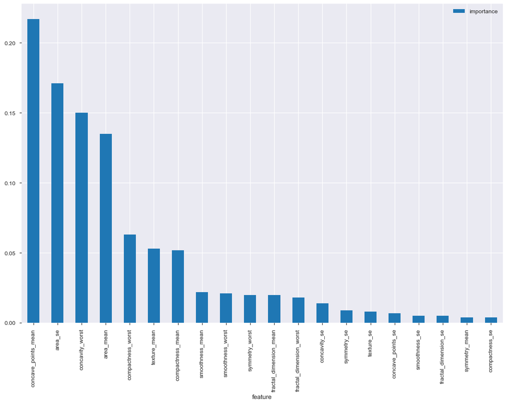

```python
from sklearn.ensemble import RandomForestClassifier
rfc = RandomForestClassifier();

# fit random forest classifier on the training set
rfc.fit(train_x, train_y);
# extract important features
score = np.round(rfc.feature_importances_,3)
importances = pd.DataFrame({'feature':train_x.columns,'importance':score})
importances = importances.sort_values('importance',ascending=False).set_index('feature')
# plot importances
plt.rcParams['figure.figsize'] = (15, 10)
importances.plot.bar();
plt.savefig("figure.png")
```

```python
test_x.to_json(orient='records')
```

[output not shown]